# Case Study 1

# Main questions of the Case Study

- Where are breweries located in the United States?
- What is the median ABV and IBU in each state?
- Who has the most alcoholic and most bitter beer?
- Is there a correlation between ABV and IBU?
- Using the data, is it possible to build a machine learning tool to categorize beer correctly?
- What are the business implecations of the data?

### Where are the breweries located in the United States?

For this question, we thought that the easiest way to display this data quickly was to create a heatmap for the data. Below is the created graphic that clearly shows that Colorado, California, Oregon, and Michigan are states with the highest number of breweries according to the data. It was a quick and easy way to see the data visualized and look at areas where competition was highest.

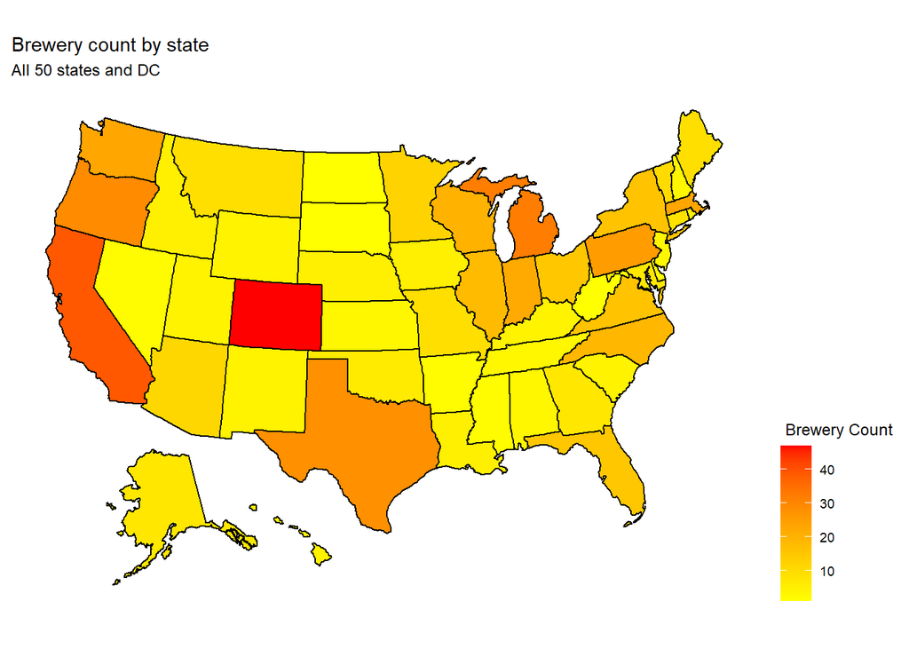

### What is the median ABV and IBU in each state?

Below you can see the median ABV and IBU for each state. These are sorted highest to lowest for convenience. We see here that the Median ABV for the country is around 5.5% and the Median IBU is around 35.

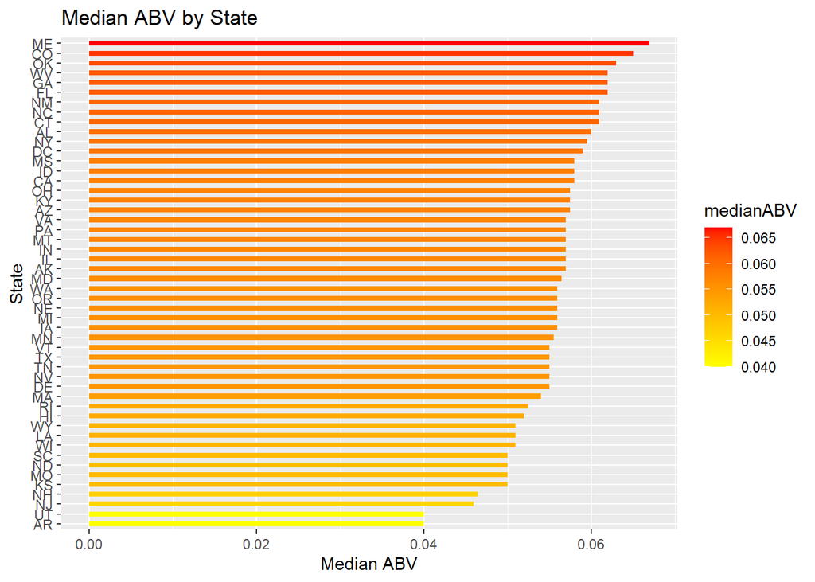

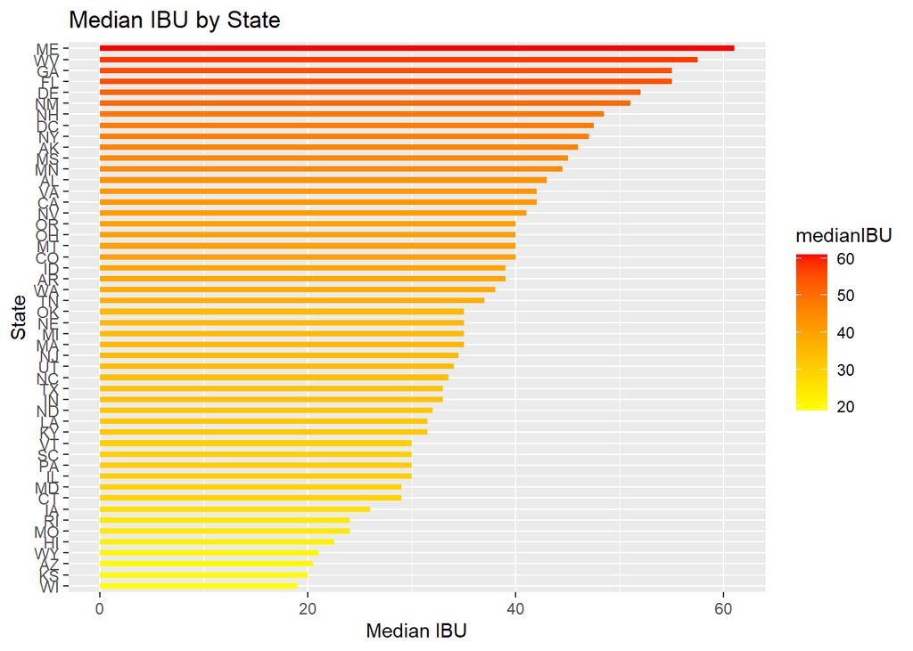

### Who has the most alcoholic and most bitter beer?

The most alcoholic beer went to a beer called London Balling out of Louisville, KY. The most bitter beer went to Bitter Bitch Imperial IPA out of Astoria, OR

### Is there a correlation between ABV and IBU?

For the next two questions we broke out the data into beer style by adding a column to help with classification. This was then plotted, and as you can see, there is a clear correlation between ABV and IBU values. This plot also showed clear clustering of the beer types that could be used for a KNN classification tool.

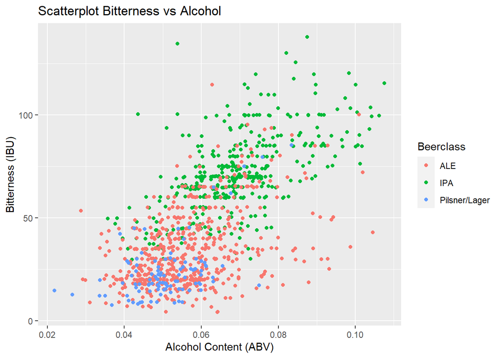

### Using the data, is it possible to build a machine learning tool to categorize beer correctly?

Since we had clear clustering, I began building out an KNN model to classify beers by type using ABV and IBU. The final model was able to classify with 74% accuracy and 88% specificity.